# Project part Total

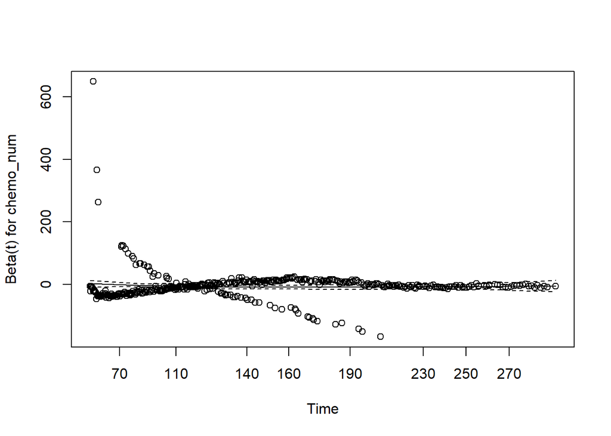

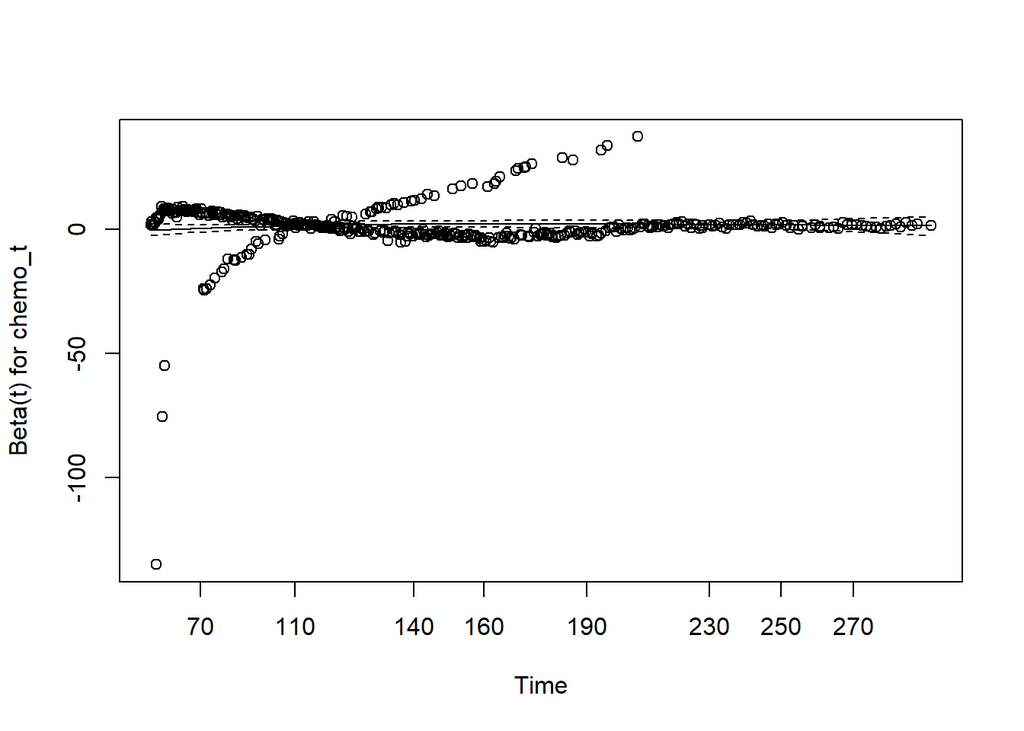

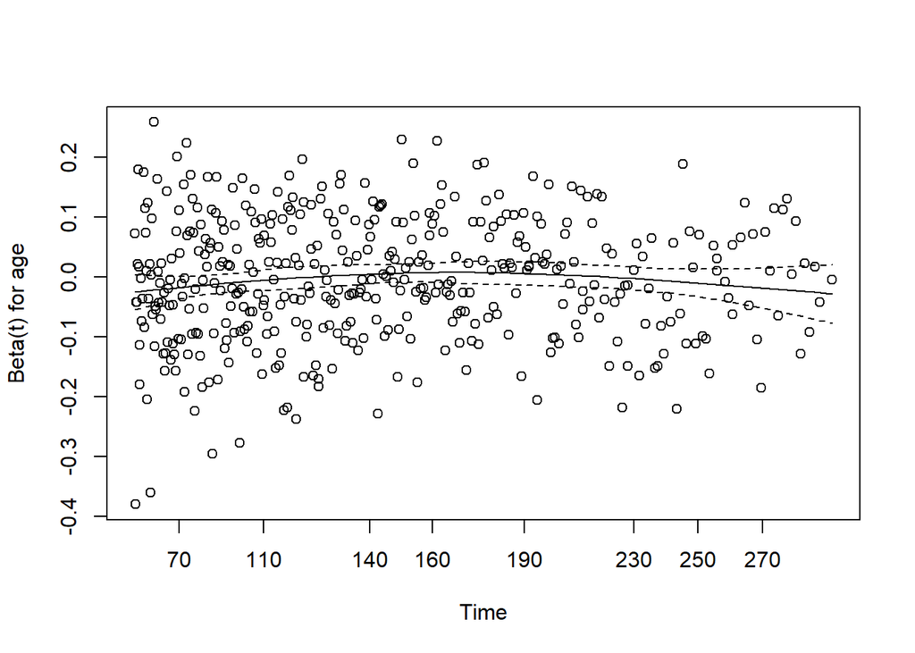

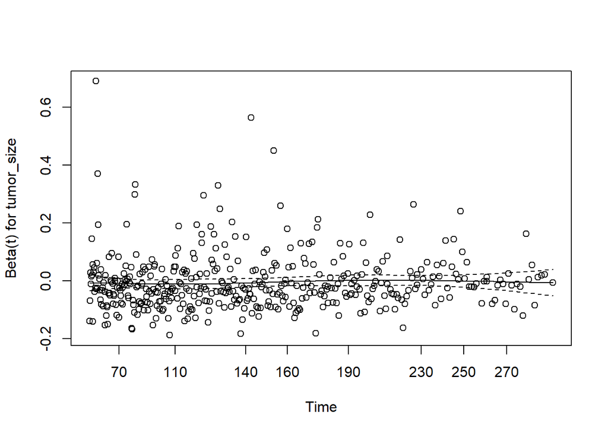

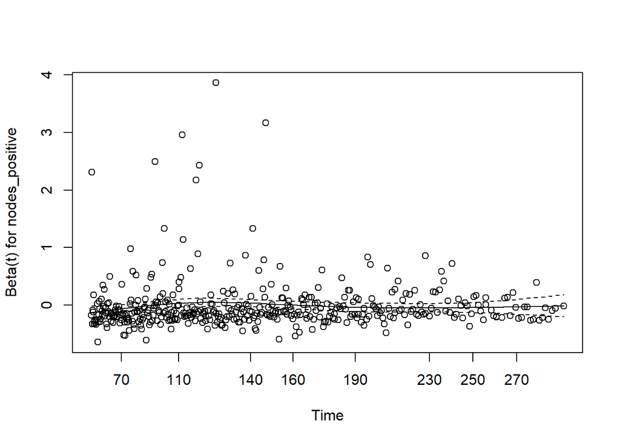

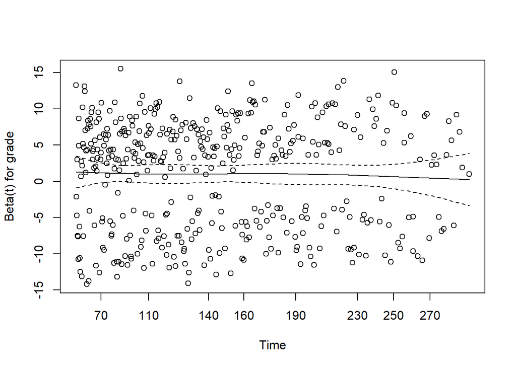

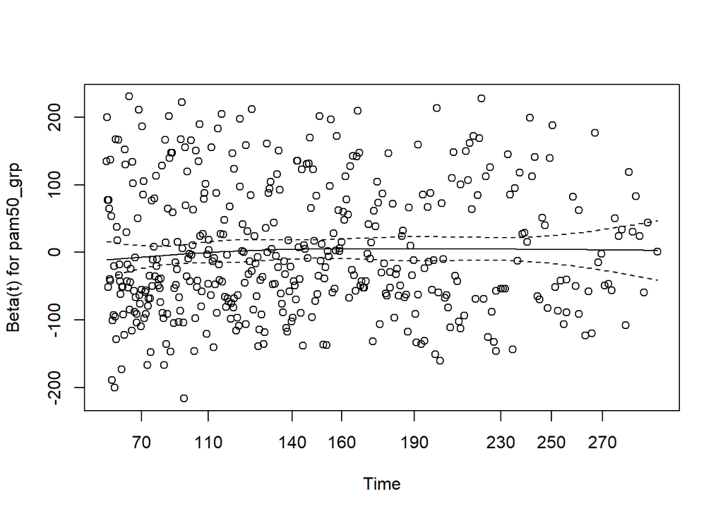

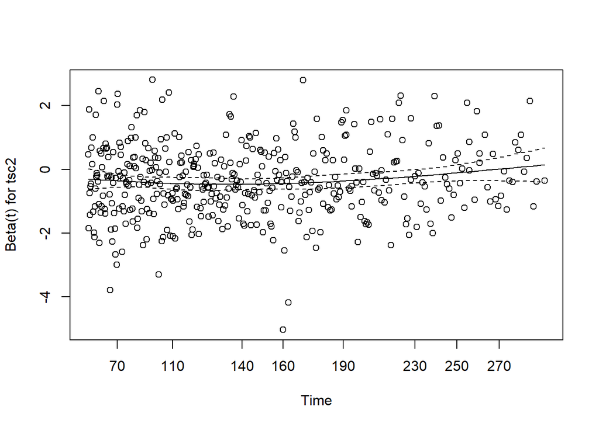

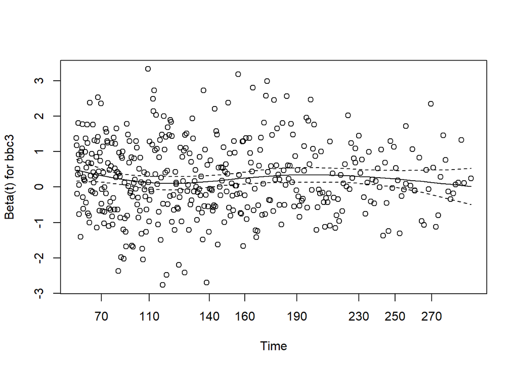

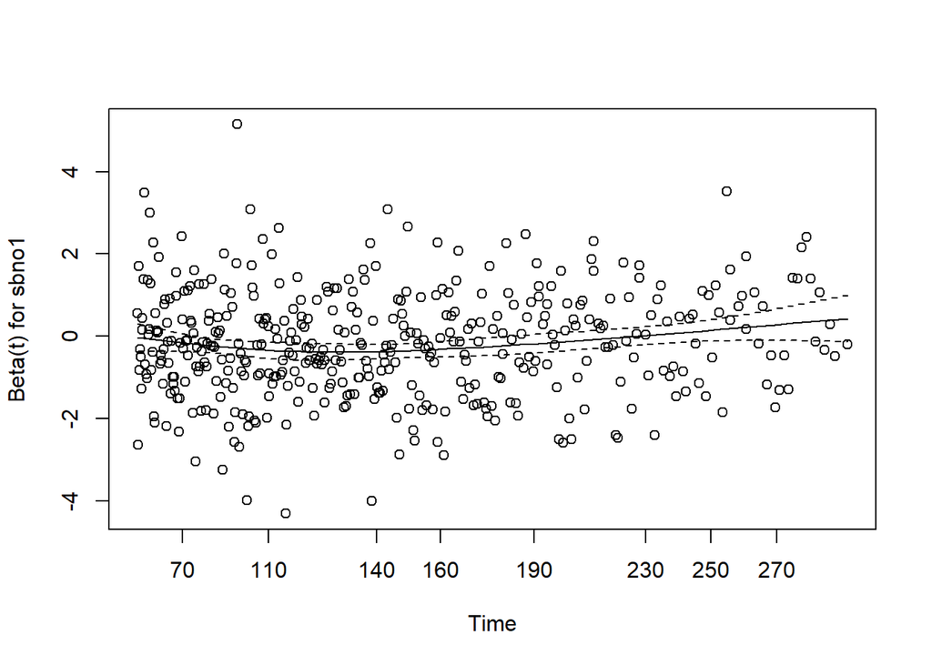

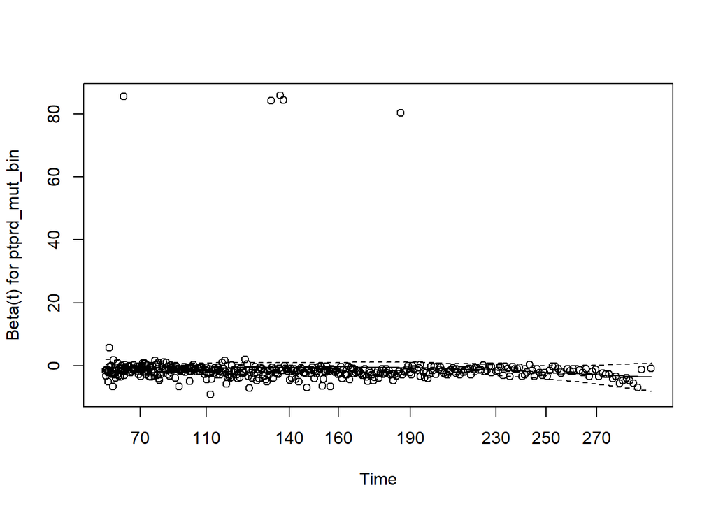

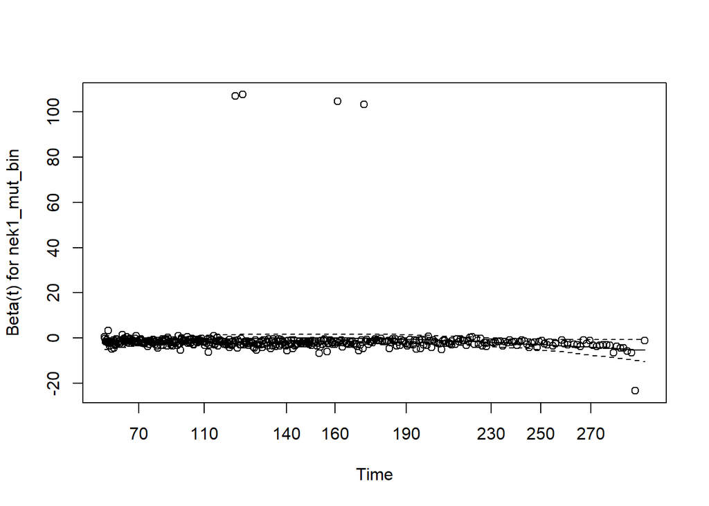

```r
plot(hx_ph_td_res)
```

### 6.4 Anderson’s plot

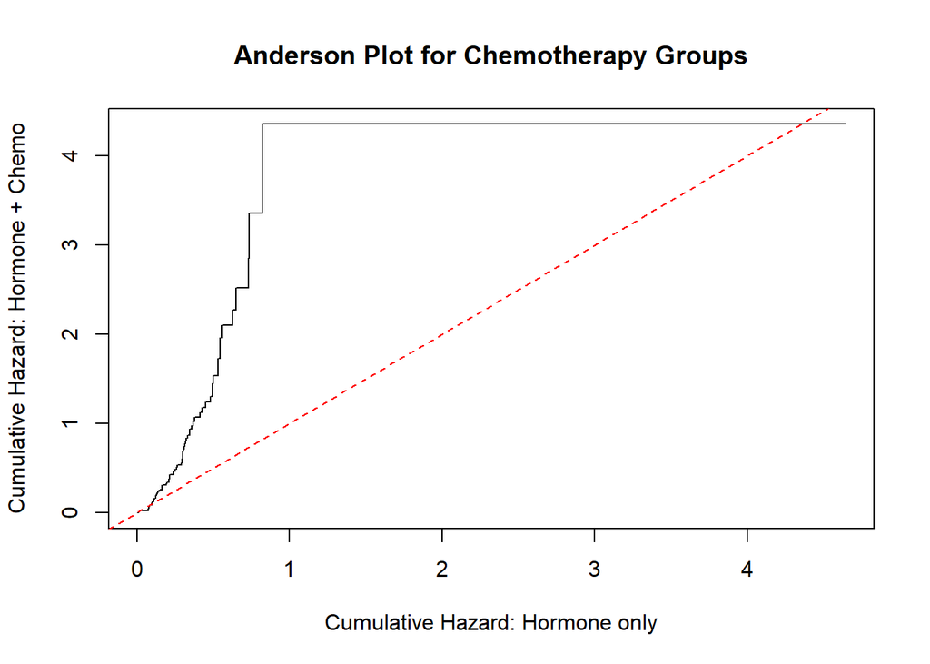

```r
# draw anderson plot
hx_reptime <- function(l, t, range_of_time) {
  x <- numeric(length(range_of_time))
  for (i in seq_along(range_of_time)) {
    dif <- range_of_time[i] - t
    dif <- dif[dif >= 0]
    if (length(dif) > 0) {
      x[i] <- l[which.min(dif)]
    } else {
      x[i] <- 0
    }
  }
  x
}

hx_dat_anderson <- hx_dat_model %>%
  mutate(chemo_num = ifelse(chemo == "Hormone + Chemo", 1, 0))

hx_fit_and <- basehaz(
  coxph(
    Surv(os_months, os_event) ~ strata(chemo_num),
    data = hx_dat_anderson,
    ties = "breslow"
  ),
  centered = FALSE
)

hx_H0 <- hx_fit_and$hazard[hx_fit_and$strata == "chemo_num=0"]
hx_H1 <- hx_fit_and$hazard[hx_fit_and$strata == "chemo_num=1"]

hx_t0 <- hx_fit_and$time[hx_fit_and$strata == "chemo_num=0"]
hx_t1 <- hx_fit_and$time[hx_fit_and$strata == "chemo_num=1"]

hx_grid_time <- sort(unique(c(hx_t0, hx_t1)))

hx_H0_rep <- hx_reptime(hx_H0, hx_t0, hx_grid_time)
hx_H1_rep <- hx_reptime(hx_H1, hx_t1, hx_grid_time)

plot(
  hx_H1_rep ~ hx_H0_rep,
  main = "Anderson Plot for Chemotherapy Groups",
  xlab = "Cumulative Hazard: Hormone only",
  ylab = "Cumulative Hazard: Hormone + Chemo",
  type = "s"
)
abline(0, 1, lty = 2, col = "red")
```

### 6.5 Cox-snell residual plot

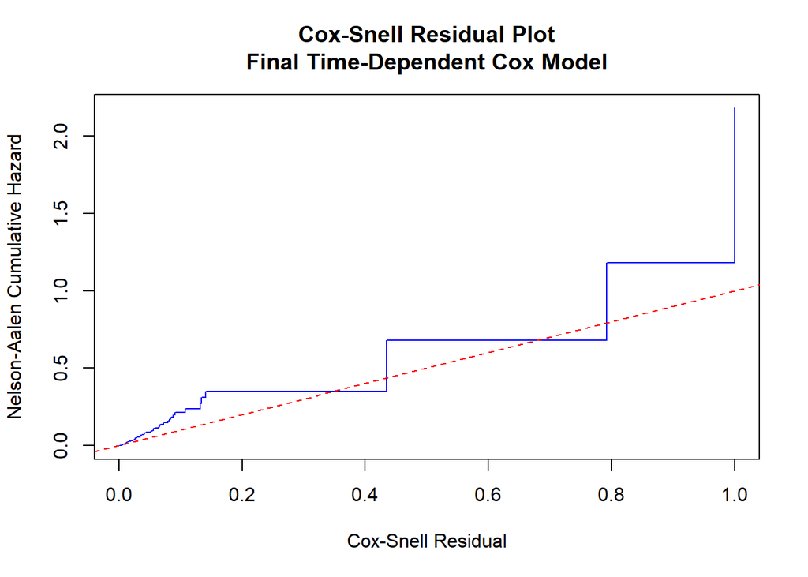

```r
# draw cox-snell residual plot
hx_cs_resid <- predict(hx_cox_td_fit, type = "expected")

hx_fit_cs <- survfit(Surv(hx_cs_resid, os_event) ~ 1, data = hx_dat_split)

hx_H_cs <- cumsum(hx_fit_cs$n.event / hx_fit_cs$n.risk)

plot(
  hx_fit_cs$time, hx_H_cs,
  type = "s",
  col = "blue",
  main = "Cox-Snell Residual Plot\nFinal Time-Dependent Cox Model",
  xlab = "Cox-Snell Residual",
  ylab = "Nelson-Aalen Cumulative Hazard"
)
abline(0, 1, col = "red", lty = 2)
```

## 7 AFT models

```r
# fit aft models
hx_aft_formula <- Surv(os_months, os_event) ~
  chemo +
  age +
  tumor_size +
  nodes_positive +
  grade +
  pam50_grp +
  tsc2 +
  bbc3 +
  sbno1 +
  ptprd_mut_bin +
  nek1_mut_bin

hx_fit_exp <- survreg(hx_aft_formula, data = hx_dat_model, dist = "exponential")
hx_fit_weib <- survreg(hx_aft_formula, data = hx_dat_model, dist = "weibull")
hx_fit_lnorm <- survreg(hx_aft_formula, data = hx_dat_model, dist = "lognormal")
hx_fit_llogis <- survreg(hx_aft_formula, data = hx_dat_model, dist = "loglogistic")
```

```r
# compare aft models
hx_model_compare <- data.frame(
  Model = c("Exponential", "Weibull", "Log-normal", "Log-logistic"),
  AIC = c(AIC(hx_fit_exp), AIC(hx_fit_weib), AIC(hx_fit_lnorm), AIC(hx_fit_llogis)),
  BIC = c(BIC(hx_fit_exp), BIC(hx_fit_weib), BIC(hx_fit_lnorm), BIC(hx_fit_llogis)),
  logLik = c(logLik(hx_fit_exp), logLik(hx_fit_weib), logLik(hx_fit_lnorm), logLik(hx_fit_llogis))
) %>%
  arrange(AIC)

hx_model_compare
```

```
         Model      AIC      BIC    logLik
1      Weibull 5119.985 5193.602 -2544.993
2 Log-logistic 5196.676 5270.292 -2583.338
3   Log-normal 5381.642 5455.259 -2675.821
4  Exponential 5538.050 5606.759 -2755.025
```

```r
# summarize aft models
summary(hx_fit_exp)
```

```
Call:
survreg(formula = hx_aft_formula, data = hx_dat_model, dist = "exponential")
                        Value Std. Error     z       p
(Intercept)           3.87146    0.32038 12.08 < 2e-16
chemoHormone + Chemo -0.27708    0.15228 -1.82  0.0688
age                   0.02129    0.00468  4.55 5.4e-06
tumor_size            0.00809    0.00457  1.77  0.0768
nodes_positive        0.03225    0.01878  1.72  0.0859
grade2                0.21554    0.14881  1.45  0.1475
grade3                0.34493    0.15923  2.17  0.0303
pam50_grpLumB         0.02127    0.12542  0.17  0.8653
pam50_grpOther        0.11658    0.12956  0.90  0.3682
tsc2                  0.27363    0.05498  4.98 6.5e-07
bbc3                 -0.14477    0.05069 -2.86  0.0043
sbno1                 0.11806    0.05632  2.10  0.0361
ptprd_mut_binYes      0.50191    0.45251  1.11  0.2674
nek1_mut_binYes       0.44023    0.45247  0.97  0.3306

Scale fixed at 1

Exponential distribution
Loglik(model)= -2755   Loglik(intercept only)= -2806.2
    Chisq= 102.43 on 13 degrees of freedom, p= 5.6e-16
Number of Newton-Raphson Iterations: 5
n= 1000
```

```r
summary(hx_fit_weib)
```

```
Call:
survreg(formula = hx_aft_formula, data = hx_dat_model, dist = "weibull")
                        Value Std. Error      z       p
(Intercept)           5.05992    0.13173  38.41 < 2e-16
chemoHormone + Chemo -0.30353    0.05859  -5.18 2.2e-07
age                   0.00232    0.00192   1.21  0.2264
tumor_size            0.00226    0.00176   1.28  0.1996
nodes_positive        0.00596    0.00738   0.81  0.4195
grade2                0.05039    0.05750   0.88  0.3808
grade3                0.14119    0.06123   2.31  0.0211
pam50_grpLumB        -0.00766    0.04908  -0.16  0.8760
pam50_grpOther        0.00814    0.04983   0.16  0.8702
tsc2                  0.13652    0.02158   6.33 2.5e-10
bbc3                 -0.08697    0.01982  -4.39 1.1e-05
sbno1                 0.06996    0.02230   3.14  0.0017
ptprd_mut_binYes      0.27147    0.17421   1.56  0.1192
nek1_mut_binYes       0.26804    0.17403   1.54  0.1235
Log(scale)           -0.95761    0.03801 -25.19 < 2e-16

Scale= 0.384

Weibull distribution
Loglik(model)= -2545   Loglik(intercept only)= -2611.1
    Chisq= 132.25 on 13 degrees of freedom, p= 7.4e-22
Number of Newton-Raphson Iterations: 7
n= 1000
```

```r
summary(hx_fit_lnorm)
```

```
Call:
survreg(formula = hx_aft_formula, data = hx_dat_model, dist = "lognormal")
                        Value Std. Error     z       p
(Intercept)           4.41693    0.20706 21.33 < 2e-16
chemoHormone + Chemo -0.14836    0.09961 -1.49  0.1364
age                   0.00877    0.00297  2.95  0.0032
tumor_size            0.00313    0.00255  1.23  0.2188
nodes_positive        0.00963    0.00933  1.03  0.3019
grade2                0.18702    0.09597  1.95  0.0513
grade3                0.22460    0.10201  2.20  0.0277
pam50_grpLumB        -0.06484    0.07515 -0.86  0.3882
pam50_grpOther        0.06728    0.08054  0.84  0.4035
tsc2                  0.18380    0.03331  5.52 3.4e-08
bbc3                 -0.14228    0.03145 -4.52 6.1e-06
sbno1                 0.08271    0.03307  2.50  0.0124
ptprd_mut_binYes      0.34055    0.23456  1.45  0.1465
nek1_mut_binYes       0.38084    0.26155  1.46  0.1454
Log(scale)           -0.30307    0.03388 -8.94 < 2e-16

Scale= 0.739

Log Normal distribution
Loglik(model)= -2675.8   Loglik(intercept only)= -2724.3
    Chisq= 97 on 13 degrees of freedom, p= 6.3e-15
Number of Newton-Raphson Iterations: 4
n= 1000
```

```r
summary(hx_fit_llogis)
```

```
Call:
survreg(formula = hx_aft_formula, data = hx_dat_model, dist = "loglogistic")
                        Value Std. Error      z       p
(Intercept)           4.74590    0.16118  29.45 < 2e-16
chemoHormone + Chemo -0.23711    0.07179  -3.30 0.00096
age                   0.00368    0.00230   1.60 0.11052
tumor_size            0.00336    0.00199   1.69 0.09126
nodes_positive        0.00605    0.00723   0.84 0.40252
grade2                0.11801    0.07311   1.61 0.10652
grade3                0.19997    0.07808   2.56 0.01043
pam50_grpLumB        -0.01579    0.05766  -0.27 0.78414
pam50_grpOther        0.01243    0.05885   0.21 0.83269
tsc2                  0.15450    0.02502   6.17 6.6e-10
bbc3                 -0.09326    0.02352  -3.96 7.4e-05
sbno1                 0.08060    0.02494   3.23 0.00123
ptprd_mut_binYes      0.24140    0.18419   1.31 0.18998
nek1_mut_binYes       0.30191    0.18939   1.59 0.11092
Log(scale)           -1.14152    0.03942 -28.96 < 2e-16

Scale= 0.319

Log logistic distribution
Loglik(model)= -2583.3   Loglik(intercept only)= -2640
    Chisq= 113.31 on 13 degrees of freedom, p= 4.2e-18
Number of Newton-Raphson Iterations: 5
n= 1000
```

```r
summary(hx_fit_weib)
```

```
Call:
survreg(formula = hx_aft_formula, data = hx_dat_model, dist = "weibull")
                        Value Std. Error      z       p
(Intercept)           5.05992    0.13173  38.41 < 2e-16
chemoHormone + Chemo -0.30353    0.05859  -5.18 2.2e-07
age                   0.00232    0.00192   1.21  0.2264
tumor_size            0.00226    0.00176   1.28  0.1996
nodes_positive        0.00596    0.00738   0.81  0.4195
grade2                0.05039    0.05750   0.88  0.3808
grade3                0.14119    0.06123   2.31  0.0211
pam50_grpLumB        -0.00766    0.04908  -0.16  0.8760
pam50_grpOther        0.00814    0.04983   0.16  0.8702
tsc2                  0.13652    0.02158   6.33 2.5e-10
bbc3                 -0.08697    0.01982  -4.39 1.1e-05
sbno1                 0.06996    0.02230   3.14  0.0017
ptprd_mut_binYes      0.27147    0.17421   1.56  0.1192
nek1_mut_binYes       0.26804    0.17403   1.54  0.1235
Log(scale)           -0.95761    0.03801 -25.19 < 2e-16

Scale= 0.384

Weibull distribution
Loglik(model)= -2545   Loglik(intercept only)= -2611.1
    Chisq= 132.25 on 13 degrees of freedom, p= 7.4e-22
Number of Newton-Raphson Iterations: 7
n= 1000
```

```r
# extract aft time ratios
hx_extract_aft_table <- function(fit) {
  tb <- as.data.frame(summary(fit)$table)
  tb$term <- rownames(tb)

  tb %>%
    mutate(
      lower = Value - 1.96 * `Std. Error`,
      upper = Value + 1.96 * `Std. Error`,
      TR = exp(Value),
      TR_lower = exp(lower),
      TR_upper = exp(upper)
    ) %>%
    select(term, Value, `Std. Error`, p, TR, TR_lower, TR_upper)
}

hx_aft_exp_table <- hx_extract_aft_table(hx_fit_exp)
hx_aft_weib_table <- hx_extract_aft_table(hx_fit_weib)
hx_aft_lnorm_table <- hx_extract_aft_table(hx_fit_lnorm)
hx_aft_llogis_table <- hx_extract_aft_table(hx_fit_llogis)

hx_aft_weib_table
```

```
                                     term        Value  Std. Error
(Intercept)                   (Intercept)  5.059922724 0.131726709
chemoHormone + Chemo chemoHormone + Chemo -0.303530222 0.058589026
age                                   age  0.002322214 0.001919652
tumor_size                     tumor_size  0.002260765 0.001762619
nodes_positive             nodes_positive  0.005955643 0.007376773
grade2                             grade2  0.050388061 0.057495566
grade3                             grade3  0.141189185 0.061229094
pam50_grpLumB               pam50_grpLumB -0.007655508 0.049076213
pam50_grpOther             pam50_grpOther  0.008141276 0.049831554
tsc2                                 tsc2  0.136523644 0.021575785
bbc3                                 bbc3 -0.086966449 0.019824174
sbno1                               sbno1  0.069964320 0.022303684
ptprd_mut_binYes         ptprd_mut_binYes  0.271468171 0.174206125
nek1_mut_binYes           nek1_mut_binYes  0.268042992 0.174034779
Log(scale)                     Log(scale) -0.957612284 0.038010336
                                 p          TR    TR_lower    TR_upper
(Intercept)           0.000000e+00 157.5783388 121.7218318 203.9973644
chemoHormone + Chemo  2.210941e-07   0.7382076   0.6581222   0.8280384
age                   2.263920e-01   1.0023249   0.9985607   1.0061033
tumor_size            1.996263e-01   1.0022633   0.9988067   1.0057319
nodes_positive        4.194645e-01   1.0059734   0.9915332   1.0206239
grade2                3.808226e-01   1.0516791   0.9395979   1.1771301
grade3                2.111529e-02   1.1516425   1.0214061   1.2984850
pam50_grpLumB         8.760391e-01   0.9923737   0.9013651   1.0925713
pam50_grpOther        8.702225e-01   1.0081745   0.9143621   1.1116119
tsc2                  2.489508e-10   1.1462820   1.0988181   1.1957961
bbc3                  1.149835e-05   0.9167079   0.8817719   0.9530279
sbno1                 1.707472e-03   1.0724699   1.0265966   1.1203930
ptprd_mut_binYes      1.191584e-01   1.3118891   0.9324164   1.8457989
nek1_mut_binYes       1.235191e-01   1.3074033   0.9295402   1.8388698
Log(scale)           4.723168e-140   0.3838082   0.3562536   0.4134941
```

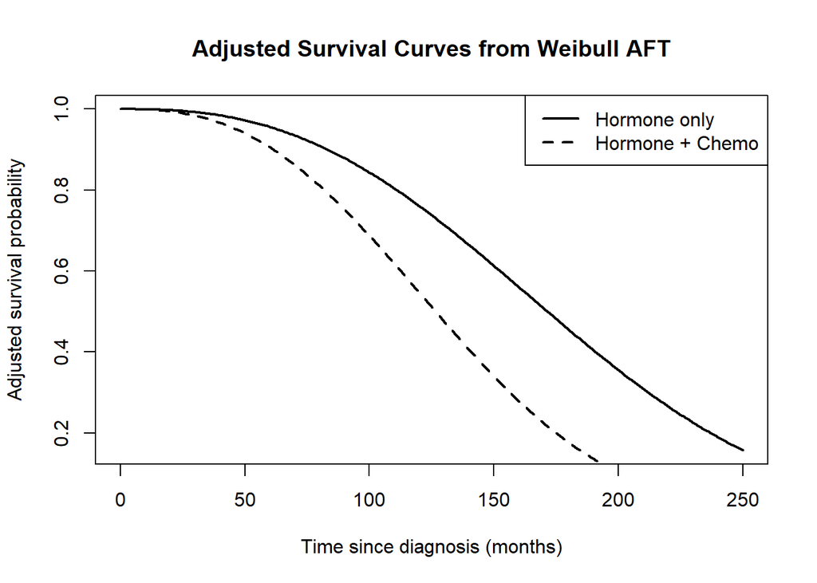

```r
# plot adjusted survival from weibull aft

library(flexsurv)
hx_fit_weib_flex <- flexsurvreg(
  hx_aft_formula,
  data = hx_dat_model,
  dist = "weibull"
)

hx_newdata_typical <- data.frame(
  chemo = factor(c("Hormone only", "Hormone + Chemo"),
                 levels = levels(hx_dat_model$chemo)),
  age = mean(hx_dat_model$age, na.rm = TRUE),
  tumor_size = mean(hx_dat_model$tumor_size, na.rm = TRUE),
  nodes_positive = mean(hx_dat_model$nodes_positive, na.rm = TRUE),
  grade = factor(levels(hx_dat_model$grade)[1], levels = levels(hx_dat_model$grade)),
  pam50_grp = factor("LumA", levels = levels(hx_dat_model$pam50_grp)),
  tsc2 = mean(hx_dat_model$tsc2, na.rm = TRUE),
  bbc3 = mean(hx_dat_model$bbc3, na.rm = TRUE),
  sbno1 = mean(hx_dat_model$sbno1, na.rm = TRUE),
  ptprd_mut_bin = factor("No", levels = levels(hx_dat_model$ptprd_mut_bin)),
  nek1_mut_bin = factor("No", levels = levels(hx_dat_model$nek1_mut_bin))
)

hx_pred <- summary(
  hx_fit_weib_flex,
  newdata = hx_newdata_typical,
  type = "survival",
  t = seq(0, 250, by = 1)
)

plot(
  hx_pred[[1]]$time, hx_pred[[1]]$est,
  type = "l", lwd = 2,
  xlab = "Time since diagnosis (months)",
  ylab = "Adjusted survival probability",
  main = "Adjusted Survival Curves from Weibull AFT"
)

lines(hx_pred[[2]]$time, hx_pred[[2]]$est, lwd = 2, lty = 2)

legend(
  "topright",
  legend = c("Hormone only", "Hormone + Chemo"),
  lwd = 2,
  lty = c(1, 2)
)
```

## 8 Model Comparisons

### 8.1 c-index

```r
# clinical-only time-dependent cox
ccox_td_score <- -predict(ccox_td_fit, type = "lp")
ccox_td_c <- concordance(
  Surv(t0, os_months, os_event) ~ ccox_td_score,
  data = dat_ccox_split
)

# weighted time-dependent cox
cox_w_td_score <- -predict(cox_w_td, type = "lp")
cox_w_td_c <- concordance(
  Surv(t0, os_months, os_event) ~ cox_w_td_score,
  data = dat_split_w
)

# crude cox + gene time-dependent
hx_cox_td_score <- -predict(hx_cox_td_fit, type = "lp")
hx_cox_td_c <- concordance(
  Surv(t0, os_months, os_event) ~ hx_cox_td_score,
  data = hx_dat_split
)

# aft (weibull)
weib_score <- predict(hx_fit_weib, type = "lp")
weib_c <- concordance(
  Surv(os_months, os_event) ~ weib_score,
  data = hx_dat_model
)

# combine results
cindex_compare <- data.frame(
  model = c(
    "Clinical-only TD Cox",
    "Weighted TD Cox",
    "TD Cox + Gene",
    "AFT Weibull"
  ),
  c_index = c(
    ccox_td_c$concordance,
    cox_w_td_c$concordance,
    hx_cox_td_c$concordance,
    weib_c$concordance
  ),
  se = c(
    sqrt(ccox_td_c$var),
    sqrt(cox_w_td_c$var),
    sqrt(hx_cox_td_c$var),
    sqrt(weib_c$var)
  )
)

cindex_compare
```

```
                 model   c_index         se
1 Clinical-only TD Cox 0.6127093 0.01719844
2      Weighted TD Cox 0.6068989 0.01686557
3        TD Cox + Gene 0.6762854 0.01559798
4          AFT Weibull 0.6708960 0.01444206
```

The concordance indices indicate moderate discriminative performance across the survival models. The clinical-only time-dependent Cox model achieved a C-index of 0.613, while the IPTW weighted time-dependent Cox model produced a very similar value of 0.607, suggesting that weighting to address confounding by indication had little impact on the model’s overall predictive discrimination. In contrast, incorporating the selected gene variables substantially improved model performance. The time-dependent Cox model with gene predictors achieved a higher C-index of 0.676, indicating better ability to distinguish patients with different survival outcomes. The Weibull AFT model showed comparable discrimination with a C-index of 0.671, suggesting that the parametric AFT framework provides similar predictive capability to the Cox model when using the same set of predictors. Overall, these results suggest that while propensity score weighting primarily adjusts treatment effect estimation, the inclusion of selected gene variables meaningfully improves the model’s ability to predict survival.